# Extra Credit - Learning Curves

Ryan LeBon

4/20/2018

This is an extra credit assignment about learning curves.

## Reading and Preprocessing Data

This is the data we are reading and processing

```r
library(caret)
dat = read.csv("https://raw.githubusercontent.com/grbruns/cst383/master/german-credit.csv")
summary(dat)
```

```
##     checking.status duration.in.months                 credit.history
##  < 0 DM     :274    Min.   : 4.0       critical               :293
##  < 200 DM   :269    1st Qu.:12.0       fully paid             : 40
##  >= 200 DM  : 63    Median :18.0       fully paid at this bank: 49
##  no checking:394    Mean   :20.9       paid to date           :530
##                     3rd Qu.:24.0       past delays            : 88
##                     Max.   :72.0
##
##                 purpose        amount            savings
##  radio/television   :280   Min.   :  250   < 100 DM  :603
##  car (new)          :234   1st Qu.: 1366   < 1000 DM : 63
##  furniture/equipment:181   Median : 2320   < 500 DM  :103
##  car (used)         :103   Mean   : 3271   >= 1000 DM: 48
##  business           : 97   3rd Qu.: 3972   unknown   :183
##  education          : 50   Max.   :18424
##  (Other)            : 55
##     employed.since percentage.of.disposable.income
##  < 1 year  :172    Min.   :1.000
##  < 4 years :339    1st Qu.:2.000
##  < 7 years :174    Median :3.000
##  >= 7 years:253    Mean   :2.973
##  unemployed: 62    3rd Qu.:4.000
##                    Max.   :4.000
##
##                       personal.status.and.sex        cosigners
##  female:divorced/separated/married:310        co-applicant: 41
##  male:divorced/separated          : 50        guarantor   : 52
##  male:married/widowed             : 92        none        :907
##  male:single                      :548
##
##
##
##  at.residence.since             property    age.in.years
##  Min.   :1.000      car or other    :332   Min.   :19.00
##  1st Qu.:2.000      real estate     :282   1st Qu.:27.00
##  Median :3.000      savings/life ins:232   Median :33.00
##  Mean   :2.845      unknown         :154   Mean   :35.55
##  3rd Qu.:4.000                             3rd Qu.:42.00
##  Max.   :4.000                             Max.   :75.00
##
```

[output cut: 17 more lines]

```
##  Min.   :1.000   none                                    :596
##  1st Qu.:1.000   yes, registered under the customers name:404
##  Median :1.000
##  Mean   :1.155
##  3rd Qu.:1.000
##  Max.   :2.000
##
##  foreign.worker   good.loan      Good.Loan
##  no : 37        Min.   :1.0   BadLoan :300
##  yes:963        1st Qu.:1.0   GoodLoan:700
##                 Median :1.0
##                 Mean   :1.3
##                 3rd Qu.:2.0
##                 Max.   :2.0
##
```

```r
# create bad loan variable

bad.loan = factor(dat$good.loan - 1)


# use only numeric data, and scale it

dat = dat[ ,c("duration.in.months", "amount", "percentage.of.disposable.income", "at.residence.since",

              "age.in.years", "num.credits.at.bank")]


dat = data.frame(scale(dat))


# add bad loan variable to data frame

dat$bad.loan = bad.loan


# structure of the data


str(dat)
```

```
## 'data.frame':    1000 obs. of  7 variables:
##  $ duration.in.months             : num  -1.236 2.247 -0.738 1.75 0.257 ...
##  $ amount                         : num  -0.745 0.949 -0.416 1.633 0.566 ...
##  $ percentage.of.disposable.income: num  0.918 -0.8697 -0.8697 -0.8697 0.0241 ...
##  $ at.residence.since             : num  1.046 -0.766 0.14 1.046 1.046 ...
##  $ age.in.years                   : num  2.765 -1.191 1.183 0.831 1.534 ...
##  $ num.credits.at.bank            : num  1.027 -0.705 -0.705 -0.705 1.027 ...
##  $ bad.loan                       : Factor w/ 2 levels "0","1": 1 2 1 1 2 1 1 1 1 2 ...
```

```r
# create training and test sets


tr_rows = sample(nrow(dat), nrow(dat)*.8)

tr_dat = dat[tr_rows,]

te_dat = dat[-tr_rows,]
```

## Learning Curve Model 1

This is a learning curve that shows use the test error rate and the training size of the data. The training size is the number of rows that are located inside of the dataset. This is good to see because the learning curve is very useful in data science. It helps in observing whether our model is having the high bias or high variance problem. The X-Axis is the number of samples (training set size) and the Y-Axis is the Error Rate ((RSS/J(theta)/cost function )). The model is fitted to the features such as; duration in months, and amount, which contribute to having a bad loan.

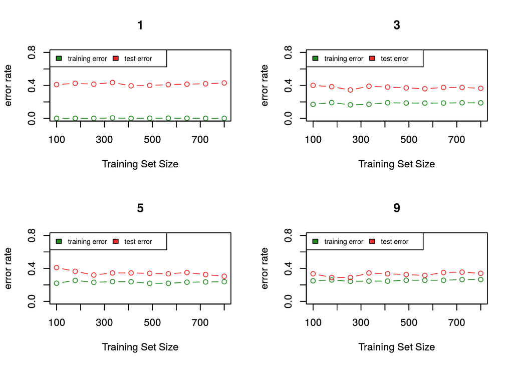

```r
create_learning_curve <- function(){
  par(mfrow=c(2,2))
  a <- seq(from=1,to=9,by=2)
  a <- a[which(!a==7)]
  for(i in a){
  # see how knn classifier works as training size changes

  k = i

  te_errs = c()

  tr_errs = c()

  te_actual = te_dat$bad.loan

  tr_sizes = seq(100, nrow(tr_dat), length.out=10)

  for (tr_size in tr_sizes) {

    tr_dat1 = tr_dat[1:tr_size,]

    tr_actual = tr_dat1$bad.loan

    fit = knn3(bad.loan ~ duration.in.months + amount, data=tr_dat1, k=k)


    # error on training set

    tr_predicted = predict(fit, tr_dat1, type="class")

    err = mean(tr_actual != tr_predicted)

    tr_errs = c(tr_errs, err)



    # error on test set

    te_predicted = predict(fit, te_dat, type="class")

    err = mean(te_actual != te_predicted)

    te_errs = c(te_errs, err)

  }

  plot(tr_sizes , tr_errs   ,type = "b" , ylim = c(0, 0.8) , ylab = "error rate", xlab="Training Set Size", col = "forestgreen",main=k)
  par(new = TRUE)
  plot(tr_sizes , te_errs   ,type = "b" ,ylim = c(0 , 0.8), ylab = "error rate" , xlab="Training Set Size", col = "firebrick2")

  legend("topleft",c("training error","test error"),fill=c("forestgreen","firebrick2"),horiz=TRUE,cex=0.7)
  }
}


create_learning_curve()
```

## Learning Curve Model 2

The learning curve is fitted to the features such as; age, and amount, which contribute to having a bad loan.

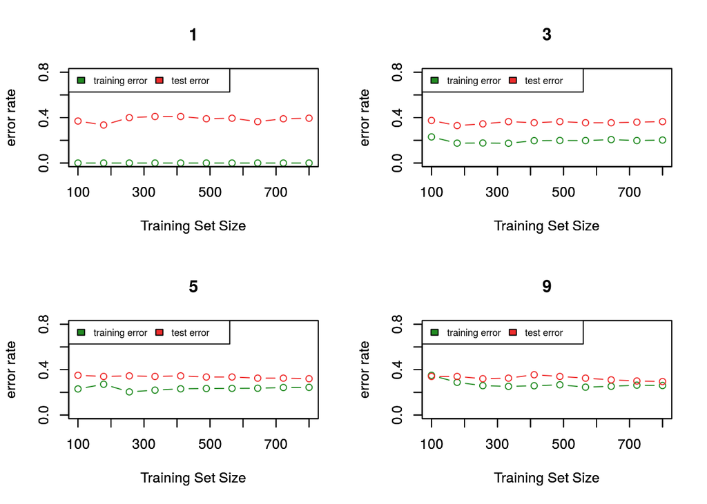

```r
create_learning_curve2 <- function(){
  par(mfrow=c(2,2))
  a <- seq(from=1,to=9,by=2)
  a <- a[which(!a==7)]
  for(i in a){
  # see how knn classifier works as training size changes

  k = i

  te_errs = c()

  tr_errs = c()

  te_actual = te_dat$bad.loan

  tr_sizes = seq(100, nrow(tr_dat), length.out=10)

  for (tr_size in tr_sizes) {

    tr_dat1 = tr_dat[1:tr_size,]

    tr_actual = tr_dat1$bad.loan

    fit = knn3(bad.loan ~ age.in.years + amount, data=tr_dat1, k=k)


    # error on training set

    tr_predicted = predict(fit, tr_dat1, type="class")

    err = mean(tr_actual != tr_predicted)

    tr_errs = c(tr_errs, err)



    # error on test set

    te_predicted = predict(fit, te_dat, type="class")

    err = mean(te_actual != te_predicted)

    te_errs = c(te_errs, err)

  }

  plot(tr_sizes , tr_errs   ,type = "b" , ylim = c(0, 0.8) , ylab = "error rate", xlab="Training Set Size", col = "forestgreen",main=k)
  par(new = TRUE)
  plot(tr_sizes , te_errs   ,type = "b" ,ylim = c(0 , 0.8), ylab = "error rate" , xlab="Training Set Size", col = "firebrick2")

  legend("topleft",c("training error","test error"),fill=c("forestgreen","firebrick2"),horiz=TRUE,cex=0.7)
  }
}

create_learning_curve2()
```

## Learning Curve Model 3

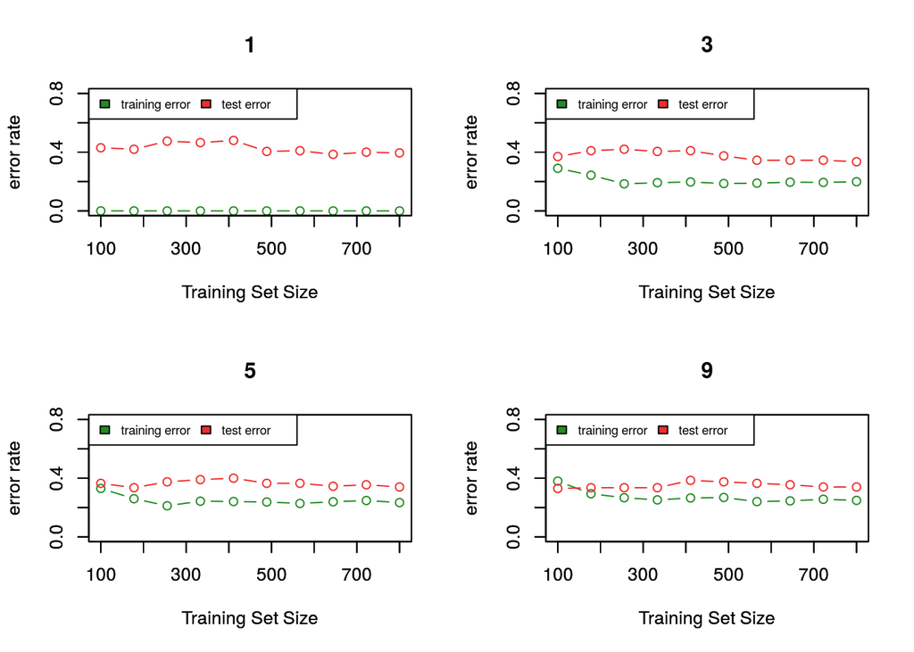

```r
create_learning_curve3 <- function(){
  par(mfrow=c(2,2))
  a <- seq(from=1,to=9,by=2)
  a <- a[which(!a==7)]
  for(i in a){
  # see how knn classifier works as training size changes

  k = i

  te_errs = c()

  tr_errs = c()

  te_actual = te_dat$bad.loan

  tr_sizes = seq(100, nrow(tr_dat), length.out=10)

  for (tr_size in tr_sizes) {

    tr_dat1 = tr_dat[1:tr_size,]

    tr_actual = tr_dat1$bad.loan

    fit = knn3(bad.loan ~ age.in.years + num.credits.at.bank +amount, data=tr_dat1, k=k)


    # error on training set

    tr_predicted = predict(fit, tr_dat1, type="class")

    err = mean(tr_actual != tr_predicted)

    tr_errs = c(tr_errs, err)



    # error on test set

    te_predicted = predict(fit, te_dat, type="class")

    err = mean(te_actual != te_predicted)

    te_errs = c(te_errs, err)

  }

  plot(tr_sizes , tr_errs   ,type = "b" , ylim = c(0, 0.8) , ylab = "error rate", xlab="Training Set Size", col = "forestgreen",main=k)
  par(new = TRUE)
  plot(tr_sizes , te_errs   ,type = "b" ,ylim = c(0 , 0.8), ylab = "error rate" , xlab="Training Set Size", col = "firebrick2")

  legend("topleft",c("training error","test error"),fill=c("forestgreen","firebrick2"),horiz=TRUE,cex=0.7)
  }
}
create_learning_curve3()
```

## Learning Curve Model 4

The learning curve is fitted to all of the features which contribute to having a bad loan.

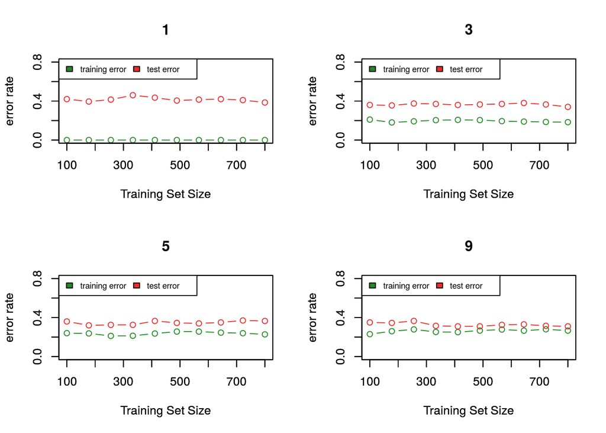

```r
create_learning_curve4 <- function(){
  par(mfrow=c(2,2))
  a <- seq(from=1,to=9,by=2)
  a <- a[which(!a==7)]
  for(i in a){
  # see how knn classifier works as training size changes

  k = i

  te_errs = c()

  tr_errs = c()

  te_actual = te_dat$bad.loan

  tr_sizes = seq(100, nrow(tr_dat), length.out=10)

  for (tr_size in tr_sizes) {

    tr_dat1 = tr_dat[1:tr_size,]

    tr_actual = tr_dat1$bad.loan

    fit = knn3(bad.loan ~ ., data=tr_dat1, k=k)


    # error on training set

    tr_predicted = predict(fit, tr_dat1, type="class")

    err = mean(tr_actual != tr_predicted)

    tr_errs = c(tr_errs, err)



    # error on test set

    te_predicted = predict(fit, te_dat, type="class")

    err = mean(te_actual != te_predicted)

    te_errs = c(te_errs, err)

  }

  plot(tr_sizes , tr_errs   ,type = "b" , ylim = c(0, 0.8) , ylab = "error rate", xlab="Training Set Size", col = "forestgreen",main=k)
  par(new = TRUE)
  plot(tr_sizes , te_errs   ,type = "b" ,ylim = c(0 , 0.8), ylab = "error rate" , xlab="Training Set Size", col = "firebrick2")

  legend("topleft",c("training error","test error"),fill=c("forestgreen","firebrick2"),horiz=TRUE,cex=0.7)
  }
}
create_learning_curve4()
```

I should have just passed params….